# Ranked Comparisons

# Goal

This notebook shows how to make ranked categorical comparisons.

Ranked plots are useful when the question is about largest, smallest, highest, lowest, or relative position.

# Analytic Questions

We will ask:

- Which states have the largest populations?
- How does a ranked plot differ from an alphabetical plot?
- How can we show a top group without hiding the denominator?

# Load Data

```r
population_path <- "data/real/state_population_ranks.csv"

state_population <- read_csv(population_path, show_col_types = FALSE)

state_population |>
  glimpse()
```

```
Rows: 51
Columns: 4
$ state      <chr> "MA", "HI", "NH", "RI", "VT", "CT", "ME", "WA", "MD", "NY",…
$ state_name <chr> "Massachusetts", "Hawaii", "New Hampshire", "Rhode Island",…
$ population <dbl> 6892503, 1415872, 1377528, 1097379, 643503, 3552824, 136235…
$ rank       <dbl> 1, 2, 3, 4, 5, 6, 7, 8, 9, 10, 11, 12, 13, 14, 15, 16, 17, …
```

Each row is one state or the District of Columbia.

# Start With An Alphabetical Plot

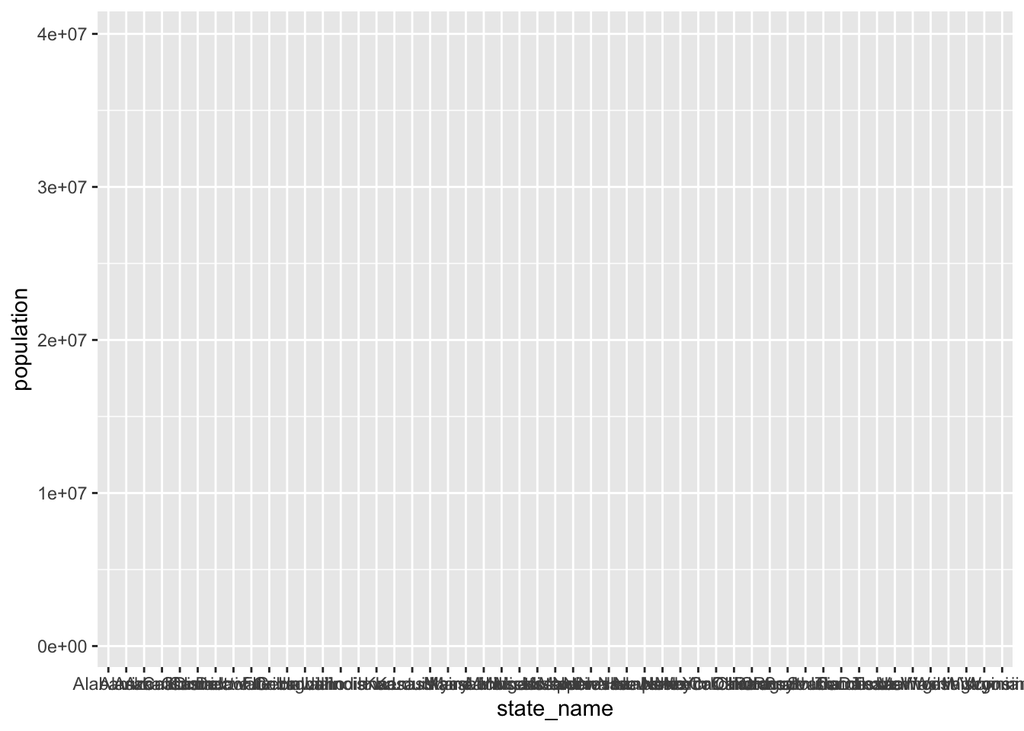

```r
p1 <- ggplot(
  state_population,
  aes(x = state_name, y = population)
)

p1
```

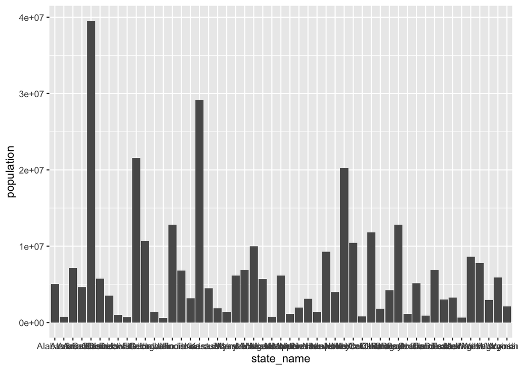

```r
p2 <- p1 +
  geom_col()

p2
```

This plot has too many labels, and alphabetical order does not fit the ranking question.

# Keep The Top 15

For a focused ranking, keep the 15 largest states.

```r
top_states <- state_population |>
  arrange(desc(population)) |>
  slice_head(n = 15) |>
  mutate(
    state_name = reorder(state_name, population),
    population_millions = population / 1000000
  )

top_states
```

```
# A tibble: 15 × 5
   state state_name     population  rank population_millions
   <chr> <fct>               <dbl> <dbl>               <dbl>
 1 CA    California       39538223    14               39.5
 2 KS    Kansas           29145505    40               29.1
 3 FL    Florida          21538187    32               21.5
 4 NY    New York         20215751    10               20.2
 5 IL    Illinois         12812508    23               12.8
 6 PA    Pennsylvania     12801989    15               12.8
 7 OH    Ohio             11799448    27               11.8
 8 GA    Georgia          10711908    35               10.7
 9 NC    North Carolina   10439388    22               10.4
10 MI    Michigan          9986857    19                9.99
11 NJ    New Jersey        9288994    18                9.29
12 VA    Virginia          8631393    21                8.63
13 WA    Washington        7797095     8                7.80
14 AZ    Arizona           7151502    36                7.15
15 TN    Tennessee         6910840    34                6.91
```

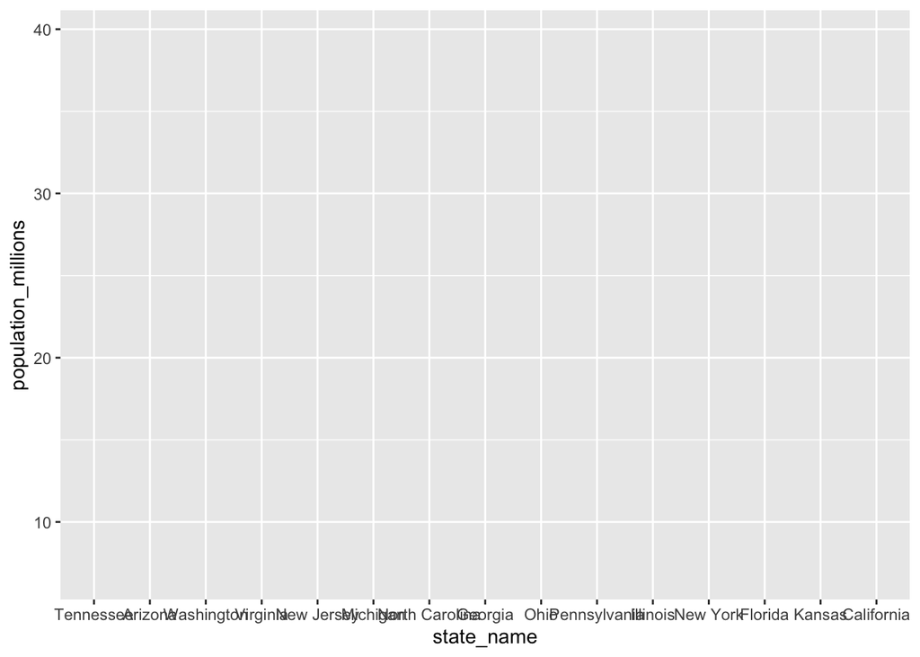

```r
p1 <- ggplot(
  top_states,
  aes(x = state_name, y = population_millions)
)

p1
```

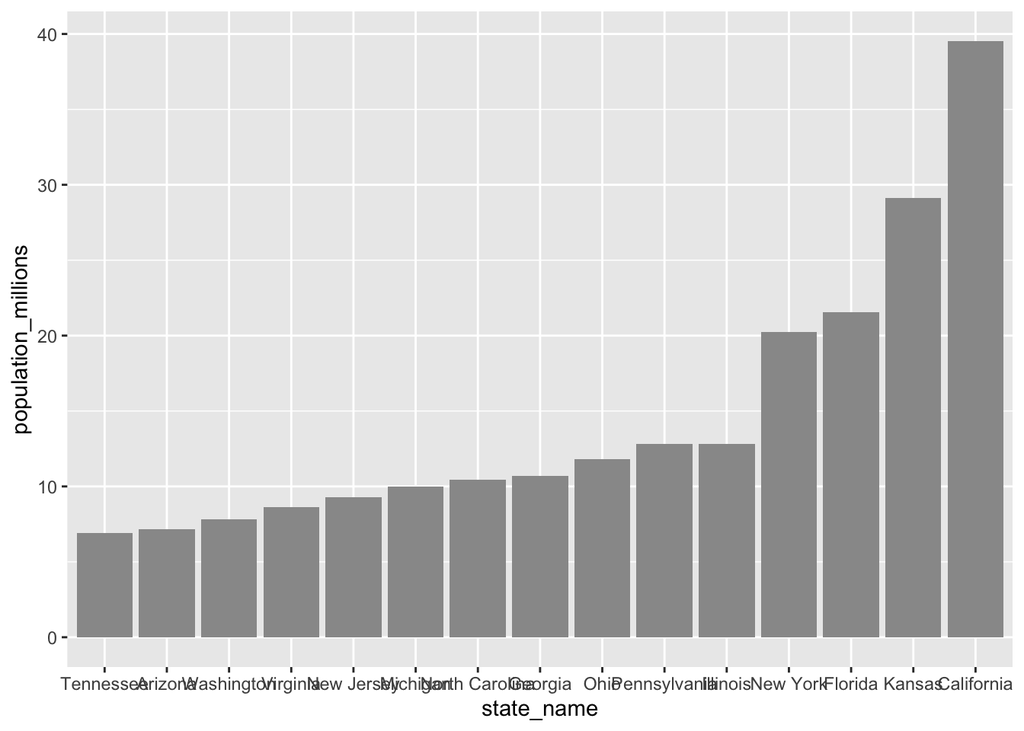

```r
p2 <- p1 +
  geom_col(fill = "gray60")

p2
```

Flip the coordinates.

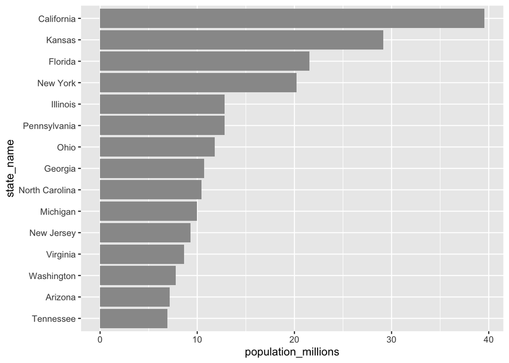

```r
p3 <- p2 +
  coord_flip()

p3
```

Add labels and a theme.

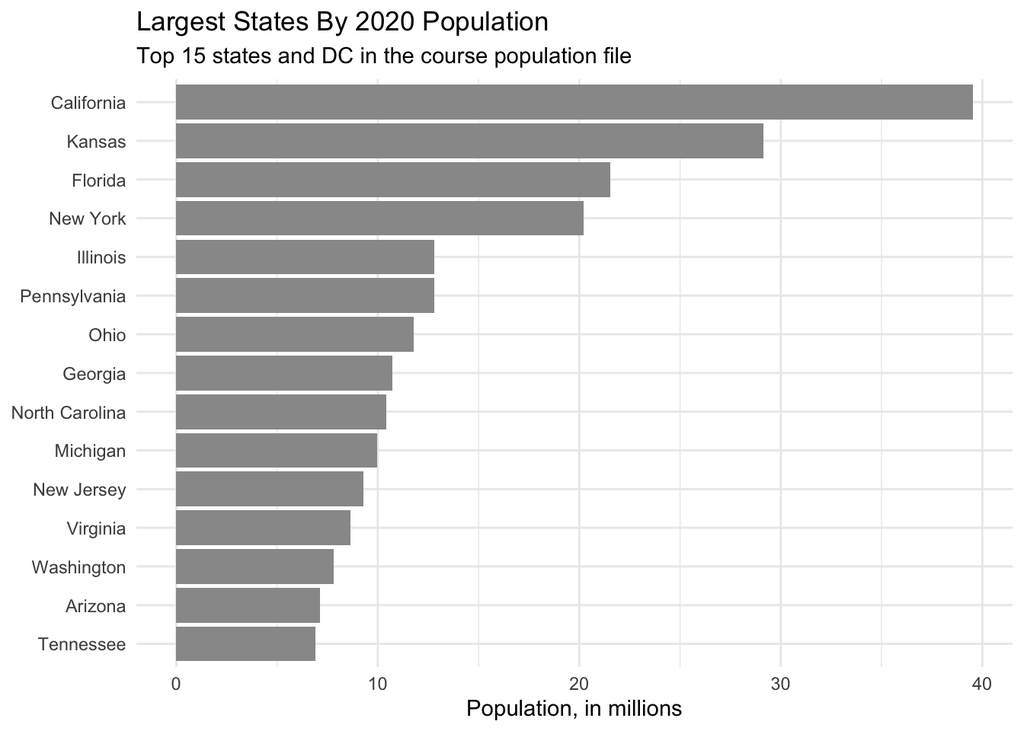

```r
p4 <- p3 +
  labs(
    title = "Largest States By 2020 Population",
    subtitle = "Top 15 states and DC in the course population file",
    x = NULL,
    y = "Population, in millions"
  ) +
  theme_minimal()

p4
```

# Use A Dot Plot For Rank

A dot plot can work well when precise bar length is less important than relative position.

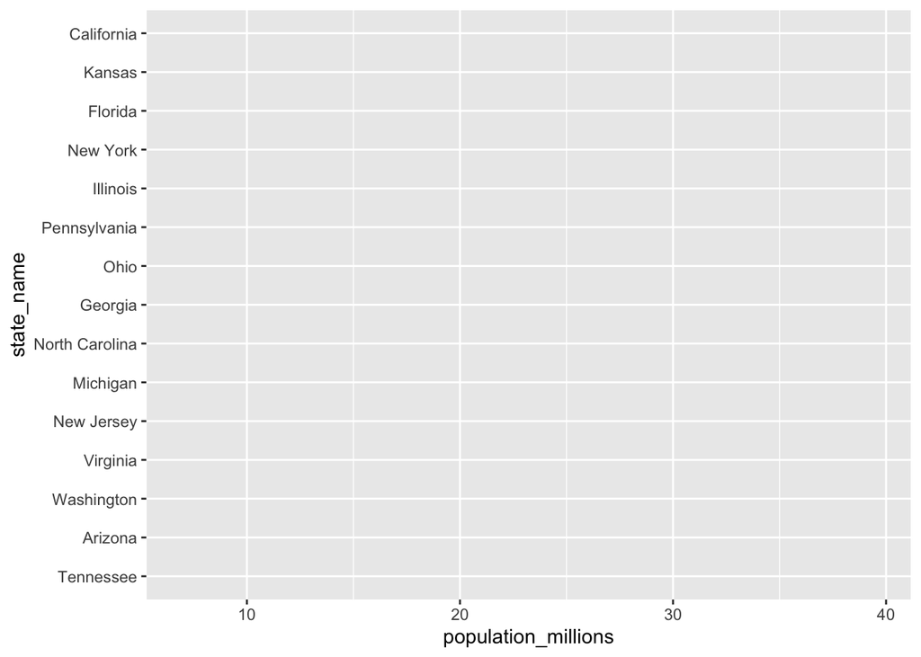

```r
p1 <- ggplot(
  top_states,
  aes(x = population_millions, y = state_name)
)

p1
```

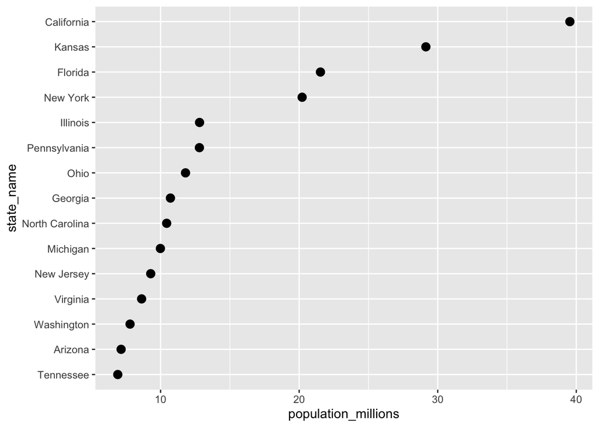

```r
p2 <- p1 +
  geom_point(size = 3)

p2
```

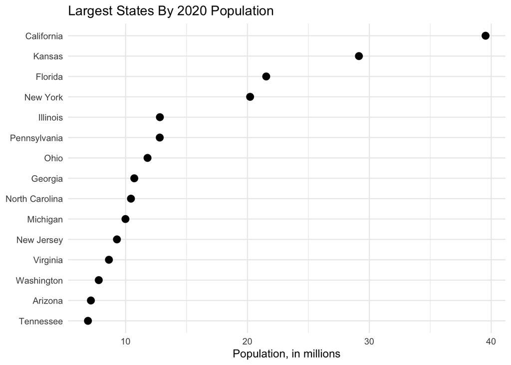

```r
p3 <- p2 +
  labs(
    title = "Largest States By 2020 Population",
    x = "Population, in millions",
    y = NULL
  ) +
  theme_minimal()

p3
```

# Highlight A Category

Highlighting can guide attention without removing the comparison group.

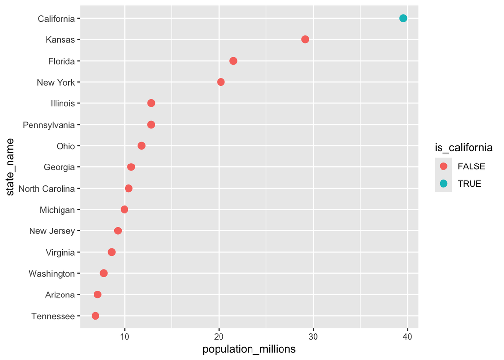

```r
top_states <- top_states |>
  mutate(is_california = state == "CA")

p1 <- ggplot(
  top_states,
  aes(
    x = population_millions,
    y = state_name,
    color = is_california
  )
) +
  geom_point(size = 3)

p1
```

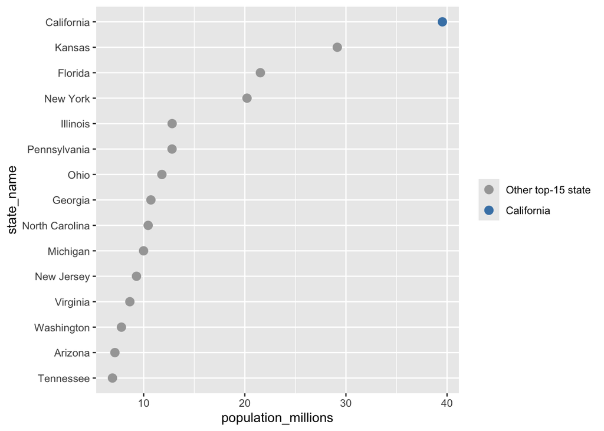

```r
p2 <- p1 +
  scale_color_manual(
    values = c("TRUE" = "steelblue", "FALSE" = "gray65"),
    labels = c("FALSE" = "Other top-15 state", "TRUE" = "California"),
    name = NULL
  )

p2
```

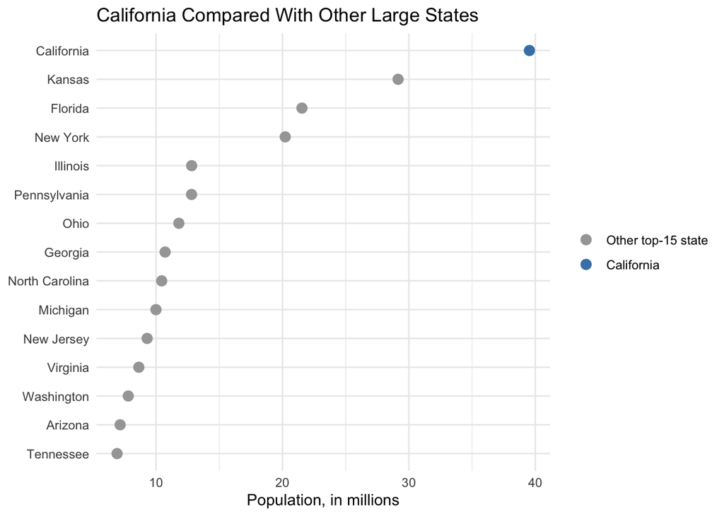

```r
p3 <- p2 +
  labs(
    title = "California Compared With Other Large States",
    x = "Population, in millions",
    y = NULL
  ) +
  theme_minimal()

p3
```

# Takeaways

- Ranking is a statistical choice and a design choice.
- Sort by the value that matches the question.
- Limit to a top or bottom group when all categories would be unreadable.
- Say clearly when the plot shows only a subset.
- Highlighting can focus attention while preserving context.